# Follow up on Windows from Yesterday

Austin Stephen

7/21/2021

### TLDR:

1. Running win percent difference was an unfair predictor because it was inclusive of the observation so it incorporated the response into the running total. I corrected this in the comparison below.
2. We have a pretty strong proxy for team strength in my eyes.
3. TODO: Need to build a model over the residuals still but have done analysis by adding fatigue factors as additional predictors (Matthew has this)
4. TODO: Random forest and gradient boosted trees over an aggregation of travel data and PDP analysis of importance.
5. QUESTION: Worth our time to check 12 and 14 game window sizes centered since it appears to get better?

### Speed mentioned in last windows rmd

- This is every player in every game of the 2014-15 season
- Very clear any relationship with in-game distance from my window rmd was just due to play time

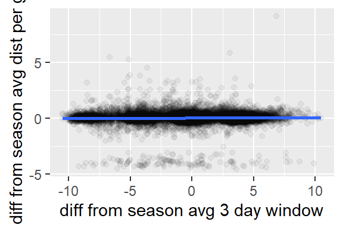

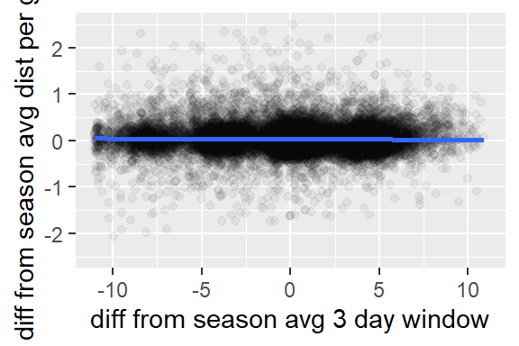

### Accounting for team strength

- This is a pretty good result I think

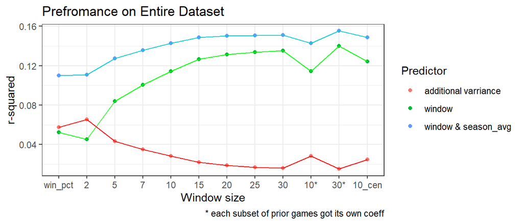

More details on 10*: I made the past 10 games window into a partition of the space using Grace’s buckets (2, 5, 7, 10) taking out duplication. Then I gave each new bucket its own coefficient with the intent of incorporating temporal information about the games into the prediction. To be more concrete, 1 and 2 games back are a variable, 3,4 and 5 games back their own variable, 6 and 7 games back, and 8-10 are their own variable in a linear model. This allows the regression to assign coefficients that give decreasing importance to buckets of games as they become more distant in time. It is essentially using “buckets” to allow the regression to find how game importance diminishes over time as opposed to me defining some heuristic. I personally don’t think the complexity of this approach is worth the payout in r-squared. However, I also think buckets will probably generalize better out of sample than the continuous version of this idea from the last meeting. Also interesting, is it accounts for about the same variance as the centered window but it does not take from the overall average in accounting for this variance.